# Integration test for MRSea 2d salsa no 1d smooth, no other variables, no panels, no interactions

LAS Scott-Hayward, C Fell

2020-08-11

2020-08-09

2020-08-10

## Introduction

This is the fourth in a series of tests that can be used to check changes to the MRSea package do not break previously working elements. They replicate the case study in the vignette but broken down into chunks. This fourth one checks the 2D salsa functions with just the 2d smooth and no other variables, no panel structure and no interactions.

```r
count.data <- read.csv("1.count.data.csv")
data <- count.data
data$response <- round(data$NHAT)
data$blockid <- paste(data$transect.id, data$season, data$impact,sep = "")
attach(data)
```

## Set up

Set a prediction grid.

```r
initialModel <- glm(response ~ 1 + offset(log(area)),
  family = "quasipoisson", data = data)
```

## Selection of flexibility for 2D smooth term

Create a grid of knots that will be used as possible knot locations.

```r
set.seed(1234)
knotgrid <- getKnotgrid(coordData = cbind(data$x.pos, data$y.pos), numKnots = 300)
```

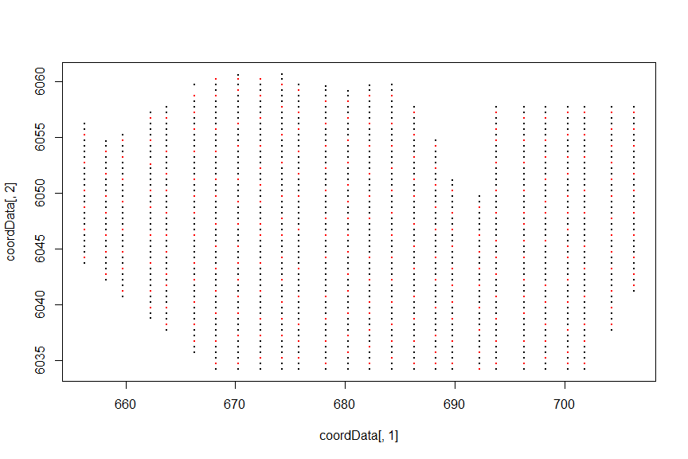

Sum of knotgrid: 2018630 this should be 2018630.

Calculate distance matrix

Sum of datadist: 8224.849 this should be 8224.849.

Sum of knotdist: 1775357 this should be 1775357.

Salsa 2D parameters

```r
salsa2dlist<-list(
  fitnessMeasure = 'cv.gamMRSea',
  knotgrid = knotgrid,
  startKnots=5,
  minKnots=4,
  maxKnots=12,
  gap=0,
  cv.opts=list(cv.gamMRSea.seed=1, K=10)
)
```

Run SALSA2D to find the appropriate number and location of knots for the 2D smooth term of `x.pos` and `y.pos`.

```r
start_time <- Sys.time()
salsa2dOutput<-runSALSA2D(initialModel, salsa2dlist,
  d2k=distMats$dataDist, k2k=distMats$knotDist, suppress.printout=TRUE)
total_time <- Sys.time() - start_time
```

## Predictions compared to original

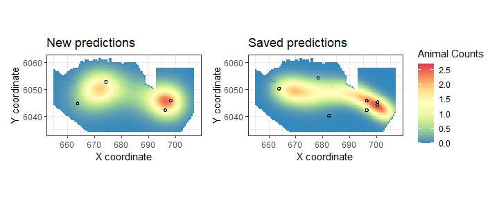

```
[1] "warning: no offset included as link response specified"
```

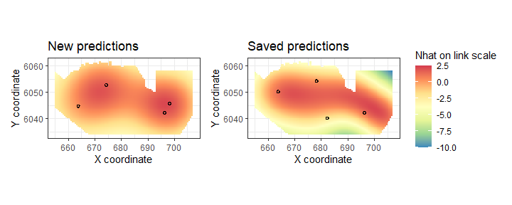

Sum of all predictions on response scale: 2154.953 this should be 2156.822.

Sum of all predictions on link scale: -606.703 this should be -4961.709.

Time for training: 2.547763

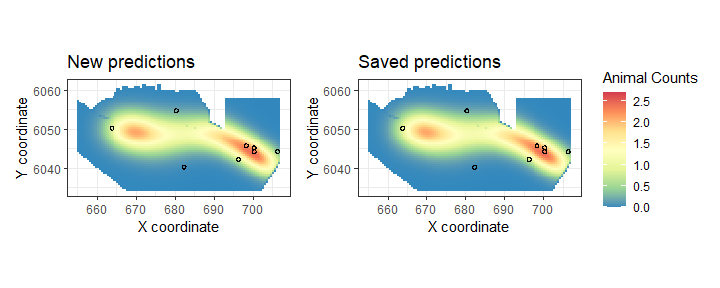

```
[1] "warning: no offset included as link response specified"
```

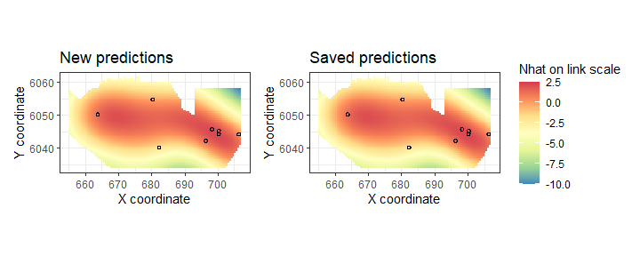

Sum of all predictions on response scale: 2157.409 this should be 2157.409.

Sum of all predictions on link scale: -4917.971 this should be -4917.971.

Time for training: 7.1 Original time: 7.7.

Number of model fits: 296 Original model fits: 296

Coefficients from new model

[output not shown]

Coefficients from saved model

| X | Estimate | Std..Error | Robust.S.E. | t.value | Pr…t.. |
| --- | --- | --- | --- | --- | --- |
| (Intercept) | -11.313 | 0.985 | 0.985 | -11.482 | 0 |
| LRF.g(radiusIndices, dists, radii, aR)b1 | 13.126 | 3.577 | 3.577 | 3.669 | 0 |
| LRF.g(radiusIndices, dists, radii, aR)b2 | 3.640 | 0.557 | 0.557 | 6.539 | 0 |
| LRF.g(radiusIndices, dists, radii, aR)b3 | 10.684 | 0.879 | 0.879 | 12.157 | 0 |
| LRF.g(radiusIndices, dists, radii, aR)b4 | -71.296 | 10.255 | 10.255 | -6.952 | 0 |
| LRF.g(radiusIndices, dists, radii, aR)b5 | 8.384 | 0.874 | 0.874 | 9.591 | 0 |
| LRF.g(radiusIndices, dists, radii, aR)b6 | -361.061 | 47.099 | 47.099 | -7.666 | 0 |
| LRF.g(radiusIndices, dists, radii, aR)b7 | 276.704 | 38.489 | 38.489 | 7.189 | 0 |
| LRF.g(radiusIndices, dists, radii, aR)b8 | 152.446 | 19.024 | 19.024 | 8.013 | 0 |

Sum of all estimates: 11.75399 this should be 18.79781.

Sum of all robust SE: 2.863787 this should be 78.3861.

Standard errors are equal to robust standard errors: TRUE

Dispersion: 13.10777 this should be 13.44141.

Mean square error: 1.087672 this should be 0.8052403.

Sum of all estimates: 21.31441 this should be 21.31441.

Sum of all robust SE: 121.7394 this should be 121.7394.

Standard errors are equal to robust standard errors: TRUE

Dispersion: 13.72587 this should be 13.72587.

Mean square error: 0.8129643 this should be 0.8129643.

residual sum square error to data: 6.091925 this should be 6.091925.

Mean square error to truth seen: 0.8860732 this should be 0.8860732.

Mean square error to truth unseen: 0.7894439 this should be 0.7894439.